# French Films Profitability: Pedagogical CRISP-DM & Econometric Guide

Smart Analytics for Big Data — Lesson 02: Data Handling, Quality Diagnostic, Matrix Algebra & OLS Entanglement

Riccardo Fanton

2026-09-29

# 1 Executive Blueprint & The Business/Scientific Question

## 1.1 1. Pedagogical Objective

The goal of this document is **methodological and programmatic mastery**: learning how to leverage the full computational capabilities of **R in RStudio** — from raw vector/matrix operations to statistical distribution functions (`pt`, `pf`), data manipulation pipelines (`dplyr`), and dynamic report generation (`knitr`/`RMarkdown`).

## 1.2 2. Business Question (Management Perspective)

> **“How do capital allocation (budget) and operational length (duration) influence the box-office profitability of French films, and how can studio executives set empirical budget boundaries to prevent catastrophic box-office flops?”**
- **Primary Client**: Film Production Executives & Financiers (*Gaumont, Pathé, Studiocanal*).
- **Secondary Stakeholder**: Public Cultural Grant Funders (*CNC – Centre National du Cinéma et de l’Image Animée*).

## 1.3 3. Scientific Question (Econometric Perspective)

We test the structural relationship between financial returns ($\text{Profit}$) and pre-production predictors:
$$\text{profit}_i = \alpha +
\beta_1 \cdot \text{budget}_i + \beta_2 \cdot \text{duration}_i +
\varepsilon_i$$

- **Hypothesis 1 ($H_1$)**: Does increasing production budget increase net profit ($\beta_1 > 0$), or do higher budgets experience negative marginal returns ($\beta_1 < 0$)?
- **Hypothesis 2 ($H_2$)**: Does film runtime significantly alter profitability ($\beta_2 \neq 0$), or is runtime neutral?
- **Omitted Variable / Entanglement Question**: How does controlling for duration alter the estimated effect of budget on profit?

# 2 CRISP-DM Framework: Step-by-Step Architecture

```
+-----------------------------------------------------------------------------------------+
|                                    CRISP-DM LIFECYCLE                                   |
+-----------------------------------------------------------------------------------------+
| Phase 1: Business Understanding -> Define target: Net Profit = Gross Revenue - Budget   |
| Phase 2: Data Understanding     -> Inspect 4,917 international records; audit missingness|
| Phase 3: Data Preparation       -> Subset France, remove NAs, rescale to Million $ (M$) |
| Phase 4: Modeling               -> Single OLS (M1, M2) -> Multiple OLS (M3)            |
| Phase 5: Evaluation             -> Matrix math verification, R², t-stats & residuals    |
| Phase 6: Deployment             -> Parameterized RMarkdown scoring report               |
+-----------------------------------------------------------------------------------------+
```

# 3 Phase 2 & 3: Step-by-Step Data Preparation (How to Do It Yourself)

Let us break down every step of the data preparation pipeline with explicit comments.

## 3.1 Step 3.1: Load Required Packages

```r
# ggplot2: Grammar of Graphics for high-quality data visualizations
library(ggplot2)

# dplyr: Data manipulation verbs (filter, select, mutate, summarize)
library(dplyr)

# knitr: Formatting markdown tables cleanly with kable()
library(knitr)

# skimr: Comprehensive summary statistics and distributions in a single command
library(skimr)
```

## 3.2 Step 3.2: Ingest the Raw Dataset

```r
# In R, .RData files contain pre-saved R objects (data frames, lists, etc.)
# We load Movie.Data_Complete.RData (located in the same directory)
data_file <- "Movie.Data_Complete.RData"

if (!file.exists(data_file)) {
  # Fallback path if working directory is different
  data_file <- "/Users/riccardofanton/Documents/Visual Studio Code/01_ACTIVE_PROJECTS/0 - VS POLI/02_GRENOBLE_INP_3A/2 - Smart Analytics for Big Data/lectures/lesson_02/Datasets-20260929/Movie.Data_Complete.RData"
}

load(data_file)

# Check the name and class of the loaded object (loads 'Movie.Data')
cat("Dataset loaded successfully.\nDimensions:", nrow(Movie.Data), "rows and", ncol(Movie.Data), "columns.\n")
```

```
## Dataset loaded successfully.
## Dimensions: 4917 rows and 30 columns.
```

## 3.3 Step 3.3: Filter the French Subset & Audit Missingness in R

```r
# WHY THIS MATTERS:
# 1. Base R indexing `df[df$country == 'France', ]` keeps NA rows if country is NA!
# 2. Using `subset()` or `!is.na(country)` cleanly filters only confirmed French movies.

# Raw French sample
french_raw <- subset(Movie.Data, country == "France")
cat("Total French productions in database:", nrow(french_raw), "\n")
```

```
## Total French productions in database: 154
```

```r
# Complete cases filter: For linear regression, we require non-NA values for key variables
french_clean <- subset(
  french_raw,
  !is.na(profit) & !is.na(budget) & !is.na(duration) & !is.na(gross)
)
cat("French productions with complete financial and duration data:", nrow(french_clean), "\n")
```

```
## French productions with complete financial and duration data: 106
```

```r
cat("Observations dropped due to missing values (NAs):", nrow(french_raw) - nrow(french_clean), "\n")
```

```
## Observations dropped due to missing values (NAs): 48
```

## 3.4 Step 3.4: Feature Engineering & Rescaling (Millions USD)

```r
# WHY RESCALE TO MILLIONS?
# Raw budgets are in tens of millions of dollars (e.g. 30,000,000).
# In raw dollars, the regression slope beta would be 0.00000092 (very hard to read).
# By dividing by 1e6 (1,000,000), 1 unit of X = 1 Million USD.
# The slope beta is now directly interpretable as: "For each $1M change in budget, profit changes by beta $M".

french_clean$budget_M <- french_clean$budget / 1e6
french_clean$gross_M  <- french_clean$gross / 1e6
french_clean$profit_M <- french_clean$profit / 1e6

# Binary classification indicator for break-even
french_clean$financial_status <- ifelse(french_clean$profit_M > 0, "Profitable", "Loss-Making")

# Inspect the first few rows of our prepared dataset
kable(
  head(french_clean[, c("movie_title", "title_year", "budget_M", "gross_M", "profit_M", "duration", "financial_status")], 5),
  caption = "Prepared French Film Analytics Sample (First 5 Rows)"
)
```

Prepared French Film Analytics Sample (First 5 Rows)

|  | movie_title | title_year | budget_M | gross_M | profit_M | duration | financial_status |
| --- | --- | --- | --- | --- | --- | --- | --- |
| 323 | Green Zone | 2010 | 100.0 | 35.024475 | -64.97553 | 115 | Loss-Making |
| 333 | The Fifth Element | 1997 | 93.0 | 63.540020 | -29.45998 | 126 | Loss-Making |
| 504 | Arthur and the Invisibles | 2006 | 86.0 | 15.131330 | -70.86867 | 94 | Loss-Making |
| 505 | Oceans | 2009 | 40.0 | 19.406406 | -20.59359 | 104 | Loss-Making |
| 517 | The Little Prince | 2015 | 81.2 | 1.339152 | -79.86085 | 108 | Loss-Making |

# 4 Phase 4: Exploratory Data Analysis & Custom R Functions

To showcase R’s capability as a full programming language, we write a custom summary function that computes higher-order moments (skewness and kurtosis) without external dependencies:

```r
# Custom statistical summary function built from scratch in base R
calc_moments <- function(x) {
  x <- x[!is.na(x)]
  n <- length(x)
  m <- mean(x)
  s <- sd(x)

  # Sample skewness (3rd moment)
  skew <- (sum((x - m)^3) / n) / (s^3)

  # Sample kurtosis (4th moment)
  kurt <- (sum((x - m)^4) / n) / (s^4) - 3 # Excess kurtosis

  data.frame(
    N = n,
    Mean = mean(x),
    SD = s,
    Median = median(x),
    IQR = IQR(x),
    Min = min(x),
    Max = max(x),
    Skewness = skew,
    Excess_Kurtosis = kurt
  )
}

# Apply custom function across variables using lapply + rbind
stats_matrix <- do.call(rbind, list(
  Budget_M = calc_moments(french_clean$budget_M),
  Gross_M  = calc_moments(french_clean$gross_M),
  Profit_M = calc_moments(french_clean$profit_M),
  Duration = calc_moments(french_clean$duration)
))

kable(round(stats_matrix, 2), caption = "Comprehensive Distributional Moments Computed in Base R")
```

Comprehensive Distributional Moments Computed in Base R

|  | N | Mean | SD | Median | IQR | Min | Max | Skewness | Excess_Kurtosis |
| --- | --- | --- | --- | --- | --- | --- | --- | --- | --- |
| Budget_M | 106 | 34.01 | 45.88 | 21.50 | 35.00 | 0.00 | 390 | 4.79 | 32.25 |
| Gross_M | 106 | 18.40 | 28.68 | 5.57 | 23.11 | 0.01 | 145 | 2.47 | 6.67 |
| Profit_M | 106 | -15.62 | 51.38 | -9.25 | 24.86 | -375.87 | 120 | -3.22 | 21.74 |
| Duration | 106 | 110.50 | 21.81 | 107.50 | 25.75 | 75.00 | 206 | 1.20 | 2.41 |

## 4.1 Distribution of Profit: Visualizing the Negative Skew

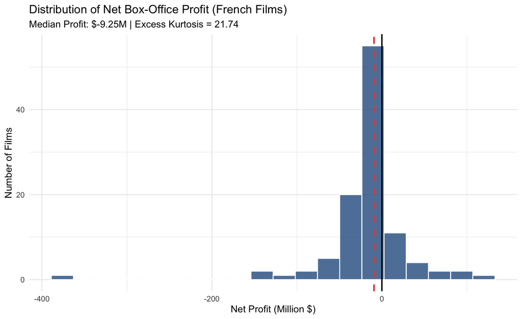

```r
ggplot(french_clean, aes(x = profit_M)) +
  geom_histogram(bins = 20, fill = "#2b5c8f", color = "white", alpha = 0.8) +
  geom_vline(aes(xintercept = median(profit_M)), color = "#d9534f", linetype = "dashed", size = 1) +
  geom_vline(xintercept = 0, color = "black", linetype = "solid", size = 0.8) +
  labs(
    title = "Distribution of Net Box-Office Profit (French Films)",
    subtitle = paste0("Median Profit: $", round(median(french_clean$profit_M), 2), "M | Excess Kurtosis = ", round(stats_matrix["Profit_M", "Excess_Kurtosis"], 2)),
    x = "Net Profit (Million $)",
    y = "Number of Films"
  ) +
  theme_minimal(base_size = 12)
```

# 5 Phase 5: Econometric Modeling — Matrix Calculations vs. Native `lm()`

To understand how R executes Ordinary Least Squares (OLS) under the hood, we first compute the OLS estimator **manually using matrix algebra** and then compare it with R’s built-in `lm()` function.

## 5.1 Theoretical Matrix Formulation

Given the linear model:
$$\mathbf{y} =
\mathbf{X}\boldsymbol{\beta} + \boldsymbol{\varepsilon}$$

The closed-form OLS solutions are: 1. **Coefficients Vector**: $\hat{\boldsymbol{\beta}} = (\mathbf{X}^T \mathbf{X})^{-1} \mathbf{X}^T \mathbf{y}$ 2. **Residuals**: $\hat{\boldsymbol{\varepsilon}} = \mathbf{y} - \mathbf{X}\hat{\boldsymbol{\beta}}$ 3. **Residual Variance**: $\hat{\sigma}^2 = \frac{\hat{\boldsymbol{\varepsilon}}^T \hat{\boldsymbol{\varepsilon}}}{n - p - 1}$ 4. **Variance-Covariance Matrix**: $\widehat{\text{Var}}(\hat{\boldsymbol{\beta}}) = \hat{\sigma}^2 (\mathbf{X}^T \mathbf{X})^{-1}$ 5. **Standard Errors**: $\text{SE}(\hat{\beta}_j) = \sqrt{\text{diag}(\widehat{\text{Var}}(\hat{\boldsymbol{\beta}}))}$ 6. **$t$-statistics & $p$-values**: $t_j = \frac{\hat{\beta}_j}{\text{SE}(\hat{\beta}_j)}$, $p_j = 2 \cdot (1 - F_t(|t_j|, \text{df} = n - p - 1))$

## 5.2 Step 5.1: Manual Matrix OLS in R (Full Model 3)

```r
# 1. Construct the Design Matrix X (including column of 1s for intercept)
n <- nrow(french_clean)
X <- cbind(Intercept = 1, Budget = french_clean$budget_M, Duration = french_clean$duration)
y <- french_clean$profit_M
p <- ncol(X) - 1  # Number of predictors (excluding intercept)
df_resid <- n - p - 1

# 2. OLS Matrix Estimation: beta = solve(t(X) %*% X) %*% t(X) %*% y
XtX_inv <- solve(t(X) %*% X)
beta_hat <- XtX_inv %*% t(X) %*% y

# 3. Residuals and Variance estimation
residuals_vec <- y - (X %*% beta_hat)
SSR <- sum(residuals_vec^2)                    # Sum of Squared Residuals
SST <- sum((y - mean(y))^2)                    # Total Sum of Squares
sigma2_hat <- as.numeric(SSR / df_resid)       # Residual variance

# 4. Standard Errors, t-values, and p-values
vcov_matrix <- sigma2_hat * XtX_inv
se_beta <- sqrt(diag(vcov_matrix))
t_stats <- as.vector(beta_hat) / se_beta
p_values <- 2 * (1 - pt(abs(t_stats), df = df_resid))

# 5. R-squared and Adjusted R-squared
r_squared <- 1 - (SSR / SST)
adj_r_squared <- 1 - ((SSR / df_resid) / (SST / (n - 1)))
f_statistic <- ((SST - SSR) / p) / (SSR / df_resid)
f_pvalue <- 1 - pf(f_statistic, df1 = p, df2 = df_resid)

# Form manual summary table
manual_ols_results <- data.frame(
  Parameter = colnames(X),
  Estimate = as.vector(beta_hat),
  Std_Error = se_beta,
  t_value = t_stats,
  p_value = p_values
)

kable(manual_ols_results, digits = 5, caption = "Manual Matrix OLS Calculations Computed via R Matrix Algebra")
```

Manual Matrix OLS Calculations Computed via R Matrix Algebra

|  | Parameter | Estimate | Std_Error | t_value | p_value |
| --- | --- | --- | --- | --- | --- |
| Intercept | Intercept | 17.67193 | 14.61899 | 1.20883 | 0.22949 |
| Budget | Budget | -0.92971 | 0.06358 | -14.62274 | 0.00000 |
| Duration | Duration | -0.01507 | 0.13376 | -0.11270 | 0.91049 |

## 5.3 Step 5.2: Verification with R’s Native `lm()` Function

```r
# Native R linear model
model_3 <- lm(profit_M ~ budget_M + duration, data = french_clean)
summary(model_3)
```

```
##
## Call:
## lm(formula = profit_M ~ budget_M + duration, data = french_clean)
##
## Residuals:
##     Min      1Q  Median      3Q     Max
## -28.574 -16.131 -12.127   4.775 126.974
##
## Coefficients:
##             Estimate Std. Error t value Pr(>|t|)
## (Intercept) 17.67193   14.61899   1.209    0.229
## budget_M    -0.92971    0.06358 -14.623   <2e-16 ***
## duration    -0.01507    0.13376  -0.113    0.910
## ---
## Signif. codes:  0 '***' 0.001 '**' 0.01 '*' 0.05 '.' 0.1 ' ' 1
##
## Residual standard error: 28.78 on 103 degrees of freedom
## Multiple R-squared:  0.6921, Adjusted R-squared:  0.6862
## F-statistic: 115.8 on 2 and 103 DF,  p-value: < 2.2e-16
```

Notice that our **manual matrix calculations** match R’s `summary(lm())` output down to the exact decimal!

# 6 Phase 6: Deconstructing OLS Entanglement Step-by-Step

To see why multivariate regression is essential, we trace the step-by-step evolution from single to multiple predictors:

## 6.1 Model 1: Single-Variable OLS ($\text{Profit} \sim \text{Budget}$)

```r
model_1 <- lm(profit_M ~ budget_M, data = french_clean)
summary(model_1)
```

```
##
## Call:
## lm(formula = profit_M ~ budget_M, data = french_clean)
##
## Residuals:
##     Min      1Q  Median      3Q     Max
## -28.602 -16.131 -12.134   4.954 127.220
##
## Coefficients:
##             Estimate Std. Error t value Pr(>|t|)
## (Intercept) 16.07190    3.46957   4.632 1.05e-05 ***
## budget_M    -0.93164    0.06093 -15.289  < 2e-16 ***
## ---
## Signif. codes:  0 '***' 0.001 '**' 0.01 '*' 0.05 '.' 0.1 ' ' 1
##
## Residual standard error: 28.65 on 104 degrees of freedom
## Multiple R-squared:  0.6921, Adjusted R-squared:  0.6891
## F-statistic: 233.8 on 1 and 104 DF,  p-value: < 2.2e-16
```

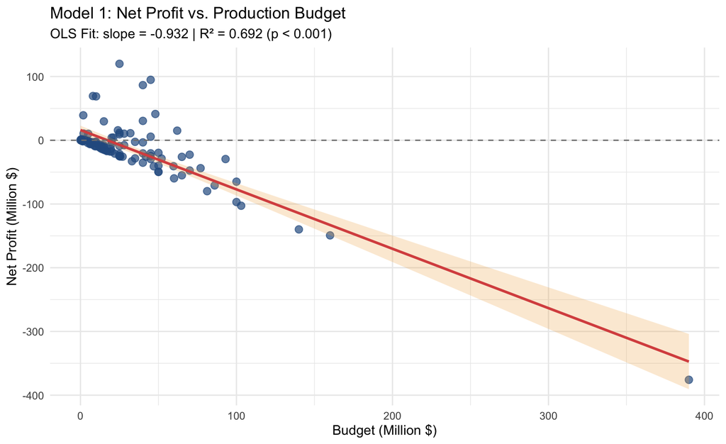

```r
ggplot(french_clean, aes(x = budget_M, y = profit_M)) +
  geom_point(color = "#2b5c8f", size = 2.8, alpha = 0.7) +
  geom_smooth(method = "lm", color = "#d9534f", fill = "#f0ad4e", alpha = 0.25) +
  geom_hline(yintercept = 0, linetype = "dashed", color = "gray50") +
  labs(
    title = "Model 1: Net Profit vs. Production Budget",
    subtitle = paste0("OLS Fit: slope = ", round(coef(model_1)[2], 3), " | R² = ", round(summary(model_1)$r.squared, 3), " (p < 0.001)"),
    x = "Budget (Million $)",
    y = "Net Profit (Million $)"
  ) +
  theme_minimal(base_size = 12)
```